# Data Science Portfolio

No tag

Publish Date: 2020-05-11

Author: Yuandong Qi

# Crash course for Python

## Introduction

Python is a general-purpose programming language that is becoming more and more popular for doing data science. Companies worldwide are using Python to harvest insights from their data and get a competitive edge. I am making a series of study notes focusing on Python specifically for data science.

## Install Python

- If you are a mac user, congratulations, you have python installed by default. You may go to your terminal, type

```python
python --version
```

to check the version of your python. If it is the latest version, good. If not, go to https://www.python.org/downloads/ to obtain the latest version. Don't worry, two python version won't have any conflict on your computer.

- If you are a windows user, you need to go to https://www.python.org/downloads/ to download.

For data science purpose, I highly recommand using Anaconda as it provides a variety of tools for data science you can download Anaconda from https://www.anaconda.com/products/individual. Just keep clicking untill you finish installing Anaconda.

Now, you are ready to start your data science journey with Python!

## Basic math operations

- Addition, subtraction
- Multiplication, division, modulo, and exponentiation

```python
5 + 5
```

```
10
```

```python
# Addition, subtraction
print(5 + 5)
print(5 - 5)

# Multiplication, division, modulo, and exponentiation
print(3 * 5)
print(10 / 2)
print(18 % 7)
print(4 ** 2)
```

```
10
0
15
5.0
4
16
```

### Exercise: How much is your 100 dollar worth after 7 years?

```python
print(100*(1.03)**7)
```

```
122.98738654248702
```

### Exercise continued

```python
# Create a variable savings
savings = 100

# Create a variable growth_multiplier
growth_multiplier=1.2

year = 7
# Calculate result
result=savings*growth_multiplier**year

# Print out result
print(result)
```

```
358.3180799999999
```

#### Type conversion

Using the + operator to paste together two strings can be very useful in building custom messages.

Suppose, for example, that you've calculated the return of your investment and want to summarize the results in a string. Assuming the floats savings and result are defined, you can try something like this:

print("I started with $" + savings + " and now have $" + result + ". Awesome!") This will not work, though, as you cannot simply sum strings and floats.

To fix the error, you'll need to explicitly convert the types of your variables. More specifically, you'll need str(), to convert a value into a string. str(savings), for example, will convert the float savings to a string.

Similar functions such as int(), float() and bool() will help you convert Python values into any type.

```python
# Fix the printout
print("I started with $" + str(savings) + " and now have $" + str(result) + ". Awesome!")
```

```
I started with $100 and now have $358.3180799999999. Awesome!
```

### Extra Exercise

```python
# Definition of pi_string
pi_string = "3.1415926"

# Convert pi_string into float: pi_float
pi_float = float(pi_string)

print(type(pi_string))

print(type(pi_float))
```

```
<class 'str'>
<class 'float'>
```

## Equality

- Comparison of booleans
- Comparison of integers
- Comparison of strings
- Compare a boolean with a numeric

```python
# Comparison of booleans
print(True == False)
```

```
False
```

```python
# Comparison of integers
print(-5 * 15 != 75)
```

```
True
```

```python
# Comparison of strings
print("pyscript" == "PyScript")
```

```
False
```

```python
# Compare a boolean with a numeric
print(True == 1)
```

```
True
```

- Comparison of integers
- Comparison of strings
- Comparison of booleans

```python
# Comparison of integers
x = -2 * 5
print(x >= -10)
```

```
True
```

## Boolean Operators in action

```python
# Define variables
my_kitchen = 18.0
your_kitchen = 14.0

# my_kitchen bigger than 10 and smaller than 18?
print(my_kitchen>10 and my_kitchen< 18)
```

```
False
```

```python
# my_kitchen smaller than 14 or bigger than 17?
print(my_kitchen<14 or my_kitchen> 17)
```

```
True
```

```python
# Double my_kitchen smaller than triple your_kitchen?
print(my_kitchen*2<your_kitchen*3)
```

```
True
```

## Boolean operators with Numpy

What is Numpy? No worries for now, more explanations later.

```python
# Create arrays
import numpy as np
my_house = np.array([18.0, 20.0, 10.75, 9.50])
your_house = np.array([14.0, 24.0, 14.25, 9.0])

# my_house greater than 18.5 or smaller than 10
print(np.logical_or(my_house>18.5, my_house<10))

# Both my_house and your_house smaller than 11
print(np.logical_and(my_house<11, your_house<11))
```

```
[False  True False  True]
[False False False  True]
```

## if, else, elif

```python
# Define variables
room = "kit"
area = 14.0
```

```python
# if statement for room
if room == "kit" :
    print("looking around in the kitchen.")
```

```python
# if statement for area
if area > 15:
    print("big place!")
```

```python
# if-else construct for room
if room == "kit" :
    print("looking around in the kitchen.")
else :
    print("looking around elsewhere.")
```

```
looking around in the kitchen.
```

```python
# Define variables
room = "bed"
area = 1.0
```

```python
# if-elif-else construct for room
if room == "kit" :
    print("looking around in the kitchen.")
elif room == "bed":
    print("looking around in the bedroom.")
else :
    print("looking around elsewhere.")
```

```
looking around in the bedroom.
```

```python
# if-elif-else construct for area
if area > 15 :
    print("big place!")
elif area> 10:
    print("medium size, nice!")
else :
    print("pretty small.")
```

```
pretty small.
```

## Lists

```python
# area variables (in square meters)
hall = 11.25
kit = 18.0
liv = 20.0
bed = 10.75
bath = 9.50

# Create list areas
areas = [hall, kit, liv, bed, bath]

# Print areas
print(areas)
```

```
[11.25, 18.0, 20.0, 10.75, 9.5]
```

```python
# Adapt list areas
areas = ["hallway", hall, "kitchen", kit, "living room", liv, "bedroom", bed, "bathroom", bath]

# Print areas
print(areas)
```

```
['hallway', 11.25, 'kitchen', 18.0, 'living room', 20.0, 'bedroom', 10.75, 'bathroom', 9.5]
```

### list of lists

```python
# area variables (in square meters)
hall = 11.25
kit = 18.0
liv = 20.0
bed = 10.75
bath = 9.50

# house information as list of lists
house = [["hallway", hall],
         ["kitchen", kit],
         ["living room", liv],
         ["bedroom", bed],
         ["bathroom", bath]]
```

```python
# Print out house
print(house)
```

```
[['hallway', 11.25], ['kitchen', 18.0], ['living room', 20.0], ['bedroom', 10.75], ['bathroom', 9.5]]
```

### subsetting lists

- python index starts with 0

```python
# Create the areas list
areas = ["hallway", 11.25, "kitchen", 18.0, "living room", 20.0, "bedroom", 10.75, "bathroom", 9.50]
```

```python
# Print out second element from areas
print(areas[2])
```

```
kitchen
```

```python
print(areas[-1])
```

```
9.5
```

### Subset and calculate

```python
# Create the areas list
areas = ["hallway", 11.25, "kitchen", 18.0, "living room", 20.0, "bedroom", 10.75, "bathroom", 9.50]

# Sum of kitchen and bedroom area: eat_sleep_area
eat_sleep_area = areas[3] + areas[-3]

# Print the variable eat_sleep_area
print(eat_sleep_area)
```

```
28.75
```

### Slicing and dicing

- include left, exclude right

```python
# Create the areas list
areas = ["hallway", 11.25, "kitchen", 18.0, "living room", 20.0, "bedroom", 10.75, "bathroom", 9.50]
```

```python
# Use slicing to create downstairs
downstairs = areas[0:5]
```

```python
# Print out downstairs and upstairs
print(downstairs)
```

```
['hallway', 11.25, 'kitchen', 18.0, 'living room']
```

```python
# Use slicing to create upstairs
upstairs = areas[6:10]
print(upstairs)
```

```
['bedroom', 10.75, 'bathroom', 9.5]
```

```python
# Alternative slicing to create downstairs
downstairs = areas[:6]

# Alternative slicing to create upstairs
upstairs = areas[:]
```

```python
print(upstairs)
```

```
['hallway', 11.25, 'kitchen', 18.0, 'living room', 20.0, 'bedroom', 10.75, 'bathroom', 9.5]
```

```python
x = [["a", "b", "c"],
     ["d", "e", "f"],
     ["g", "h", "i"]]
```

```python
print(x)
```

```
[['a', 'b', 'c'], ['d', 'e', 'f'], ['g', 'h', 'i']]
```

```python
print(x[2][:2])
```

```
['g', 'h']
```

### list manipulation

```python
# Create the areas list
areas = ["hallway", 11.25, "kitchen", 18.0, "living room", 20.0, "bedroom", 10.75, "bathroom", 9.50]
```

```python
# Correct the bathroom area
areas[-1] = 10.50

areas[4] = "chill zone" # Change "living room" to "chill zone"

print(areas)
```

```
['hallway', 11.25, 'kitchen', 18.0, 'chill zone', 20.0, 'bedroom', 10.75, 'bathroom', 10.5]
```

```python
# Create the areas list (updated version)
areas = ["hallway", 11.25, "kitchen", 18.0, "living room", 20.0,
         "bedroom", 10.75, "bathroom", 10.50]
```

```python
print(areas)
```

```
['hallway', 11.25, 'kitchen', 18.0, 'living room', 20.0, 'bedroom', 10.75, 'bathroom', 10.5]
```

```python
# Add poolhouse data to areas, new list is areas_1
areas_1 = areas + ["poolhouse", 24.5]
print(areas_1)
```

```
['hallway', 11.25, 'kitchen', 18.0, 'living room', 20.0, 'bedroom', 10.75, 'bathroom', 10.5, 'poolhouse', 24.5]
```

```python
# Add garage data to areas_1, new list is areas_2
areas_2 = areas_1 + ["garage", 15.45]
print(areas_2)
```

```
['hallway', 11.25, 'kitchen', 18.0, 'living room', 20.0, 'bedroom', 10.75, 'bathroom', 10.5, 'poolhouse', 24.5, 'garage', 15.45]
```

```python
areas = ["hallway", 11.25, "kitchen", 18.0,
        "chill zone", 20.0, "bedroom", 10.75,
         "bathroom", 10.50, "poolhouse", 24.5,
         "garage", 15.45]
```

```python
print(areas)
```

```
['hallway', 11.25, 'kitchen', 18.0, 'chill zone', 20.0, 'bedroom', 10.75, 'bathroom', 10.5, 'poolhouse', 24.5, 'garage', 15.45]
```

```python
del(areas[-4:-2])
print(areas)
```

```
['hallway', 11.25, 'kitchen', 18.0, 'chill zone', 20.0, 'bedroom', 10.75, 'bathroom', 10.5, 'garage', 15.45]
```

### Inner workings of lists

```python
# Create list areas
areas = [11.25, 18.0, 20.0, 10.75, 9.50]

# Create areas_copy
areas_copy = areas

# Change areas_copy
areas[0] = 5.0

# Print areas
print(areas_copy)
```

```
[5.0, 18.0, 20.0, 10.75, 9.5]
```

## Function

```python
# Create variables var1 and var2
var1 = [1, 2, 3, 4]
var2 = True
```

```python
# Print out type of var1
print(type(var2))
```

```
<class 'bool'>
```

```python
# Print out length of var1
print(len(var1))
```

```
4
```

```python
help(len)
```

```
Help on built-in function len in module builtins:

len(obj, /)
    Return the number of items in a container.
```

```python
# Create lists first and second
first = [11.25, 18.0, 20.0]
second = [10.75, 9.50]

# Paste together first and second: full
full = first + second
print(full)
```

```
[11.25, 18.0, 20.0, 10.75, 9.5]
```

```python
# Sort full in descending order: full_sorted
full_sorted = sorted(full, reverse = True)

# Print out full_sorted
print(full_sorted)
```

```
[20.0, 18.0, 11.25, 10.75, 9.5]
```

## Object and method

- In python, everything is an object and an object has methods associated with
- Methods: functions that belong to objects

```python
# string to experiment with: place
place = "poolhouse"

# Use upper() on place: place_up
place_up = place.upper()

# Print out place and place_up
print(place)
print(place_up)
```

```
poolhouse
POOLHOUSE
```

```python
# Print out the number of o's in place
print(place.count("o"))
```

```
3
```

## List Methods

```python
# Create list areas
areas = [11.25, 18.0, 20.0, 10.75, 9.50]

# Print out the index of the element 20.0
print(areas.index(20.0))
```

```
2
```

```python
# Print out how often 9.50 appears in areas
print(areas.count(9.50))
```

```
1
```

```python
# Create list areas
areas = [11.25, 18.0, 20.0, 10.75, 9.50]
```

```python
# Use append twice to add poolhouse and garage size
areas.append(24.5)
areas.append(15.45)
# Print out areas
print(areas)
```

```
[11.25, 18.0, 20.0, 10.75, 9.5, 24.5, 15.45]
```

```python
# Reverse the orders of the elements in areas
areas.reverse()
print(areas)
```

```
[15.45, 24.5, 9.5, 10.75, 20.0, 18.0, 11.25]
```

## packages: directory of python scripts

- Each script = module
- Specify functions, methods, types
- Thousands of packages available
- Numpy
- pandas
- Matplotlib
- Scikit-learn

### Import package

```python
# Import the math package
import math
import pandas as pd
# Definition of radius
r = 0.43

# Calculate C
C = 2 * r * math.pi
print(C)
```

```
2.701769682087222
```

```python
# Calculate A
A = math.pi * r ** 2

# Build printout
print("Circumference: " + str(C)) # str means string
print("Area: " + str(A))
```

```
Circumference: 2.701769682087222
Area: 0.5808804816487527
```

### Selective import

```python
# Import radians function of math package
from math import radians

# Definition of radius
r = 192500

# Travel distance of Moon over 12 degrees. Store in dist.
dist = r * radians(12)

# Print out dist
print(dist)
```

```
40317.10572106901
```

## Numeric Python

- Alternative to Python List: NumPy Array
- Calculations over entire arrays
- Easy and Fast

```python
# Create arrays
import numpy as np

my_house   =[18.0, 20.0, 10.75, 9.50]
your_house =[14.0, 24.0, 14.25, 9.0]
```

```python
print(my_house>=18)
```

```
---------------------------------------------------------------------------
TypeError                                 Traceback (most recent call last)
<ipython-input-86-2dd0b3bcab97> in <module>
----> 1 print(my_house>=18)

TypeError: '>=' not supported between instances of 'list' and 'int'
```

```python
np_my_house = np.array(my_house)
np_your_house = np.array(your_house)

# my_house greater than or equal to 18
print(np_my_house>=18)
```

```
[ True  True False False]
```

```python
# Print out type of my house
print(my_house)
print(type(my_house))
```

```
[18.0, 20.0, 10.75, 9.5]
<class 'list'>
```

```python
print(np_my_house)
print(type(np_my_house))
```

```
[18.   20.   10.75  9.5 ]
<class 'numpy.ndarray'>
```

```python
# height is available as a regular list

height_in=[74,
 74,
 72,
 72,
 73,
 69,
 69,
 71]
```

```python
# Create a numpy array from height_in: np_height_in
np_height_in = np.array(height_in)

# Print out np_height_in
print(np_height_in)

# Convert np_height to m: np_height_m
np_height_m = np_height_in * 0.0254

# Print np_height_m
print(np_height_m)
```

```
[74 74 72 72 73 69 69 71]
[1.8796 1.8796 1.8288 1.8288 1.8542 1.7526 1.7526 1.8034]
```

```python
# height and weight are available as regular lists
weight_lb =  [208,
 225,
 190,
 225,
 185,
 180,
 165,
 90]
```

```python
# Create array from height_in with metric units: np_height_m
np_height_m = np.array(height_in) * 0.0254

# Create array from weight_lb with metric units: np_weight_kg
np_weight_kg = np.array(weight_lb) * 0.453592

# Calculate the BMI: bmi
bmi = np_weight_kg / np_height_m ** 2

# Print out bmi
print(bmi)
```

```
[26.70532383 28.88797049 25.76834706 30.51514784 24.40753727 26.58105883
 24.3659706  12.55231314]
```

```python
# Create the light array
light = bmi < 21

# Print out light
print(light)

# Print out BMIs of all baseball players whose BMI is below 21
print(bmi[light])
```

```
[False False False False False False False  True]
[12.55231314]
```

### NumPy Side Effects

If you compare its functionality with regular Python lists, however, some things have changed.

- Numpy arrays cannot contain elements with different types. If you try to build such a list, some of the elements' types are changed to end up with a homogeneous list. This is known as type coercion.
- The typical arithmetic operators, such as +, -, * and / have a different meaning for regular Python lists and numpy arrays.

```python
# Create baseball, a list of lists
baseball = [[180, 78.4],
            [215, 102.7],
            [210, 98.5],
            [188, 75.2]]

# Create a 2D numpy array from baseball: np_baseball
np_baseball = np.array(baseball)

# Print out the type of np_baseball
print(type(np_baseball))
```

```
<class 'numpy.ndarray'>
```

```python
print(np_baseball)
```

```
[[180.   78.4]
 [215.  102.7]
 [210.   98.5]
 [188.   75.2]]
```

```python
# Print out the shape of np_baseball
print(np_baseball.shape)
```

```
(4, 2)
```

```python
np_baseball[:,0]
```

```
array([180., 215., 210., 188.])
```

### NumPy: Basic Statistics

```python
# Create np_height_in from np_baseball
np_height_in = np_baseball[:,0]
```

```python
np_height_in
```

```
array([180., 215., 210., 188.])
```

```python
# Print out the mean of np_height_in
print(np.mean(np_height_in))
```

```
198.25
```

```python
# Print mean height (first column)
avg = np.mean(np_baseball[:,0])
print("Average: " + str(avg))
```

```
Average: 198.25
```

```python
# Print out the median of np_height_in
print(np.median(np_height_in))
```

```
199.0
```

```python
# Print median height. Replace 'None'
med = np.median(np_baseball[:,0])
print("Median: " + str(med))
```

```
Median: 199.0
```

简单来说，标准差是一组数值自平均值分散开来的程度的一种测量观念。一个较大的标准差，代表大部分的数值和其平均值之间差异较大；一个较小的标准差，代表这些数值较接近平均值。

```python
# Print out the standard deviation on height. Replace 'None'
stddev = np.std(np_baseball[:,0])
print("Standard Deviation: " + str(stddev))
```

```
Standard Deviation: 14.635146053251399
```

```python
# Print out correlation between first and second column. Replace 'None'
corr = np.corrcoef(np_baseball[:,0], np_baseball[:,1])
print("Correlation: " + str(corr))
```

```
Correlation: [[1.         0.95865738]
 [0.95865738 1.        ]]
```

## Index and value

```python
# Definition of countries and capital
countries = ['spain', 'france', 'germany', 'norway']
capitals = ['madrid', 'paris', 'berlin', 'oslo']

# Get index of 'germany': ind_ger
ind_ger = countries.index('germany')

# Use ind_ger to print out capital of Germany
print(capitals[ind_ger])
```

```
berlin
```

## Dictionary

```python
# Definition of dictionary
europe = {'spain':'madrid', 'france':'paris', 'germany':'berlin', 'norway':'oslo' }
```

```python
# Print out the keys in europe
print(europe.keys())

# Print out value that belongs to key 'norway'
print(europe['norway'])
```

```
dict_keys(['spain', 'france', 'germany', 'norway'])
oslo
```

```python
# Definition of dictionary
europe = {'spain':'madrid', 'france':'paris', 'germany':'berlin', 'norway':'oslo' }

# Add italy to europe
europe['italy'] = 'rome'

# Print out italy in europe
print('italy' in europe)
```

```
True
```

```python
europe
```

```
{'spain': 'madrid',
 'france': 'paris',
 'germany': 'berlin',
 'norway': 'oslo',
 'italy': 'rome'}
```

```python
# Add poland to europe
europe['poland'] = 'warsaw'

# Print europe
print(europe)
```

```
{'spain': 'madrid', 'france': 'paris', 'germany': 'berlin', 'norway': 'oslo', 'italy': 'rome', 'poland': 'warsaw'}
```

```python
# Definition of dictionary
europe = {'spain':'madrid', 'france':'paris', 'germany':'bonn',
          'norway':'oslo', 'italy':'rome', 'poland':'warsaw',
          'australia':'vienna' }

# Print europe
print(europe)

# Update capital of germany
europe['germany'] = 'berlin'

# Print europe
print(europe)
```

```
{'spain': 'madrid', 'france': 'paris', 'germany': 'bonn', 'norway': 'oslo', 'italy': 'rome', 'poland': 'warsaw', 'australia': 'vienna'}
{'spain': 'madrid', 'france': 'paris', 'germany': 'berlin', 'norway': 'oslo', 'italy': 'rome', 'poland': 'warsaw', 'australia': 'vienna'}
```

```python
# Remove australia
del(europe['australia'])

# Print europe
print(europe)
```

```
{'spain': 'madrid', 'france': 'paris', 'germany': 'berlin', 'norway': 'oslo', 'italy': 'rome', 'poland': 'warsaw'}
```

### Dictionary of dictionaries

```python
europe = { 'spain': { 'capital':'madrid', 'population':46.77 },
           'france': { 'capital':'paris', 'population':66.03 },
           'germany': { 'capital':'berlin', 'population':80.62 },
           'norway': { 'capital':'oslo', 'population':5.084 } }


# Print out the capital of France
print(europe['france']['capital'])
```

```
paris
```

```python
# Create sub-dictionary data
data = { 'capital':'rome', 'population':59.83 }

# Add data to europe under key 'italy'
europe['italy'] = data

# Print europe
print(europe)
```

```
{'spain': {'capital': 'madrid', 'population': 46.77}, 'france': {'capital': 'paris', 'population': 66.03}, 'germany': {'capital': 'berlin', 'population': 80.62}, 'norway': {'capital': 'oslo', 'population': 5.084}, 'italy': {'capital': 'rome', 'population': 59.83}}
```

## Pandas

Pandas is the building block and fundation of data science with Python, we cover some basics here and a seperate class with pandas will follow.

- dictionary is very useful, you can think of keys as data columns, and values as the content of each column.
- let us build a pandas dataframe from a dictionary

```python
import pandas as pd

# Build cars DataFrame
names = ['United States', 'Australia', 'Japan', 'India', 'Russia', 'Morocco', 'Egypt']
dr =  [True, False, False, False, True, True, True]
cpc = [809, 731, 588, 18, 200, 70, 45]
dict = { 'country':names, 'drives_right':dr, 'cars_per_cap':cpc }
cars = pd.DataFrame(dict)
print(cars)
```

```
         country  drives_right  cars_per_cap
0  United States          True           809
1      Australia         False           731
2          Japan         False           588
3          India         False            18
4         Russia          True           200
5        Morocco          True            70
6          Egypt          True            45
```

```python
# Definition of row_labels
row_labels = ['US', 'AUS', 'JAP', 'IN', 'RU', 'MOR', 'EG']

# Specify row labels of cars
cars.index = row_labels

# Print cars again
print(cars)
```

```
           country  drives_right  cars_per_cap
US   United States          True           809
AUS      Australia         False           731
JAP          Japan         False           588
IN           India         False            18
RU          Russia          True           200
MOR        Morocco          True            70
EG           Egypt          True            45
```

- Here, we have index for each row, which is like the label/name of the row, we can access/slice data using the index

```python
# Print out country column as Pandas Series
print(cars['country'])
```

```
US     United States
AUS        Australia
JAP            Japan
IN             India
RU            Russia
MOR          Morocco
EG             Egypt
Name: country, dtype: object
```

```python
# Print out country column as Pandas DataFrame
print(cars[['country']])
```

```
           country
US   United States
AUS      Australia
JAP          Japan
IN           India
RU          Russia
MOR        Morocco
EG           Egypt
```

```python
# Print out DataFrame with country and drives_right columns
print(cars[['country', 'drives_right']])
```

```
           country  drives_right
US   United States          True
AUS      Australia         False
JAP          Japan         False
IN           India         False
RU          Russia          True
MOR        Morocco          True
EG           Egypt          True
```

```python
# Print out first 3 observations
print(cars[0:3])
```

```
           country  drives_right  cars_per_cap
US   United States          True           809
AUS      Australia         False           731
JAP          Japan         False           588
```

```python
# Print out fourth, fifth and sixth observation
print(cars[3:6])
```

```
     country  drives_right  cars_per_cap
IN     India         False            18
RU    Russia          True           200
MOR  Morocco          True            70
```

## loc and iloc

```python
# Print out observation for Japan
print(cars.loc['JAP'])
```

```
country         Japan
drives_right    False
cars_per_cap      588
Name: JAP, dtype: object
```

```python
# Print out observations for Australia and Egypt
print(cars.loc[['AUS', 'EG']])
```

```
       country  drives_right  cars_per_cap
AUS  Australia         False           731
EG       Egypt          True            45
```

```python
print(cars.loc['IN', 'cars_per_cap'])
```

```
18
```

```python
# Print out drives_right value of Morocco
print(cars.loc['MOR', 'drives_right'])
```

```
True
```

```python
# Print sub-DataFrame
print(cars.loc[['RU', 'MOR'], ['country', 'drives_right']])
```

```
     country  drives_right
RU    Russia          True
MOR  Morocco          True
```

```python
# Print out drives_right column as Series
print(cars.loc[:, 'drives_right'])
```

```
US      True
AUS    False
JAP    False
IN     False
RU      True
MOR     True
EG      True
Name: drives_right, dtype: bool
```

```python
print(cars.iloc[:, 1])
```

```
US      True
AUS    False
JAP    False
IN     False
RU      True
MOR     True
EG      True
Name: drives_right, dtype: bool
```

```python
# Print out drives_right column as DataFrame
print(cars.loc[:, ['drives_right']])
```

```
     drives_right
US           True
AUS         False
JAP         False
IN          False
RU           True
MOR          True
EG           True
```

```python
print(cars.iloc[:, [1]])
```

```
     drives_right
US           True
AUS         False
JAP         False
IN          False
RU           True
MOR          True
EG           True
```

```python
print(type(cars.iloc[:, 1]))
```

```
<class 'pandas.core.series.Series'>
```

```python
print(type(cars.iloc[:, [1]]))
```

```
<class 'pandas.core.frame.DataFrame'>
```

```python
# Print out cars_per_cap and drives_right as DataFrame
print(cars.loc[:, [ 'cars_per_cap', 'drives_right']])
```

```
     cars_per_cap  drives_right
US            809          True
AUS           731         False
JAP           588         False
IN             18         False
RU            200          True
MOR            70          True
EG             45          True
```

### Filtering Pandas DataFrame

```python
# Extract drives_right column as Series: dr
dr = cars['drives_right']==True

# Use dr to subset cars: sel
sel = cars[dr]

# Print sel
print(sel)
```

```
           country  drives_right  cars_per_cap
US   United States          True           809
RU          Russia          True           200
MOR        Morocco          True            70
EG           Egypt          True            45
```

```python
# Convert code to a one-liner
sel = cars[cars['drives_right']==True]

# Print sel
print(sel)
```

```
           country  drives_right  cars_per_cap
US   United States          True           809
RU          Russia          True           200
MOR        Morocco          True            70
EG           Egypt          True            45
```

```python
# Create car_maniac: observations that have a cars_per_cap over 500
car_maniac = cars[cars['cars_per_cap']>500]

# Print car_maniac
print(car_maniac)
```

```
           country  drives_right  cars_per_cap
US   United States          True           809
AUS      Australia         False           731
JAP          Japan         False           588
```

```python
import numpy as np

# Create medium: observations with cars_per_cap between 100 and 500
medium = cars[np.logical_and(cars['cars_per_cap']>100, cars['cars_per_cap']<500)]

# Print medium
print(medium)
```

```
   country  drives_right  cars_per_cap
RU  Russia          True           200
```

## Loop

### While loop

```python
# Initialize offset
offset = 8

# Code the while loop
while offset != 0:
    print("correcting...")
    offset = offset - 1
    print(offset)
```

```
correcting...
7
correcting...
6
correcting...
5
correcting...
4
correcting...
3
correcting...
2
correcting...
1
correcting...
0
```

```python
# Add conditionals

# Initialize offset
offset = -6

# Code the while loop
while offset != 0 :
    print("correcting...")
    if offset > 0:
        offset = offset - 1
    else:
        offset = offset + 1
    print(offset)
```

```
correcting...
-5
correcting...
-4
correcting...
-3
correcting...
-2
correcting...
-1
correcting...
0
```

### for loop

```python
# areas list
areas = [11.25, 18.0, 20.0, 10.75, 9.50]

# Code the for loop
for i in areas:
    print(i)
```

```
11.25
18.0
20.0
10.75
9.5
```

```python
# areas list
areas = [11.25, 18.0, 20.0, 10.75, 9.50]

# Change for loop to use enumerate() and update print()
for index, size in enumerate(areas) :
    print("room "+ str(index) + ": " + str(size))
```

```
room 0: 11.25
room 1: 18.0
room 2: 20.0
room 3: 10.75
room 4: 9.5
```

```python
# areas list
areas = [11.25, 18.0, 20.0, 10.75, 9.50]

# Code the for loop
for index, area in enumerate(areas) :
    print("room " + str(index+1) + ": " + str(area))
```

```
room 1: 11.25
room 2: 18.0
room 3: 20.0
room 4: 10.75
room 5: 9.5
```

```python
# house list of lists
house = [["hallway", 11.25],
         ["kitchen", 18.0],
         ["living room", 20.0],
         ["bedroom", 10.75],
         ["bathroom", 9.50]]

# Build a for loop from scratch

for i in house:
    print("the " + str(i[0])+ " is" + " " + str(i[1])+ " sqm")
```

```
the hallway is 11.25 sqm
the kitchen is 18.0 sqm
the living room is 20.0 sqm
the bedroom is 10.75 sqm
the bathroom is 9.5 sqm
```

### Loop over dictionary

```python
# Definition of dictionary
europe = {'spain':'madrid', 'france':'paris', 'germany':'berlin',
          'norway':'oslo', 'italy':'rome', 'poland':'warsaw', 'austria':'vienna' }

# Iterate over europe
for k, v in europe.items():
    print ("the capital of " + k + " is " + v)
```

```
the capital of spain is madrid
the capital of france is paris
the capital of germany is berlin
the capital of norway is oslo
the capital of italy is rome
the capital of poland is warsaw
the capital of austria is vienna
```

### Loop over data frame by rows:

```python
# Iterate over rows of cars
for lab, row in cars.iterrows():
    print(lab)
    print(row)
```

```
US
country         United States
drives_right             True
cars_per_cap              809
Name: US, dtype: object
AUS
country         Australia
drives_right        False
cars_per_cap          731
Name: AUS, dtype: object
JAP
country         Japan
drives_right    False
cars_per_cap      588
Name: JAP, dtype: object
IN
country         India
drives_right    False
cars_per_cap       18
Name: IN, dtype: object
RU
country         Russia
drives_right      True
cars_per_cap       200
Name: RU, dtype: object
MOR
country         Morocco
drives_right       True
cars_per_cap         70
Name: MOR, dtype: object
EG
country         Egypt
drives_right     True
cars_per_cap       45
Name: EG, dtype: object
```

```python
# Adapt for loop
for lab, row in cars.iterrows() :
    print(lab + ": " + str(row['cars_per_cap']))
```

```
US: 809
AUS: 731
JAP: 588
IN: 18
RU: 200
MOR: 70
EG: 45
```

```python
# Code for loop that adds COUNTRY column
for lab, row in cars.iterrows() :
    cars.loc[lab, "COUNTRY"] = row["country"].upper()

# Print cars
print(cars)
```

```
           country  drives_right  cars_per_cap        COUNTRY
US   United States          True           809  UNITED STATES
AUS      Australia         False           731      AUSTRALIA
JAP          Japan         False           588          JAPAN
IN           India         False            18          INDIA
RU          Russia          True           200         RUSSIA
MOR        Morocco          True            70        MOROCCO
EG           Egypt          True            45          EGYPT
```

```python
# Use .apply(str.upper)
cars["COUNTRY"] = cars['country'].apply(str.upper)

print(cars)
```

```
           country  drives_right  cars_per_cap        COUNTRY
US   United States          True           809  UNITED STATES
AUS      Australia         False           731      AUSTRALIA
JAP          Japan         False           588          JAPAN
IN           India         False            18          INDIA
RU          Russia          True           200         RUSSIA
MOR        Morocco          True            70        MOROCCO
EG           Egypt          True            45          EGYPT
```

## Wrap up with a case study

```python
# Import numpy as np
import numpy as np

# Set the seed
np.random.seed(123)

# Generate and print random float
print(np.random.rand())
```

```
0.6964691855978616
```

```python
# Set the seed
np.random.seed(123)

# Use randint() to simulate a dice
print(np.random.randint(1, 7))

# Use randint() again
print(np.random.randint(1, 7))
```

```
6
3
```

```python
# Set the seed
np.random.seed(123)

# Starting step
step = 50

# Roll the dice
dice = np.random.randint(1, 7)

# Finish the control construct
if dice <= 2 :
    step = step - 1
elif dice < 6:
    step = step + 1
else :
    step = step + np.random.randint(1,7)

# Print out dice and step
print(str(dice) + " "+ str(step))
```

```
6 53
```

```python
# Set the seed
np.random.seed(123)

# Initialize random_walk
random_walk = [0]

for x in range(100) :
    # Set step: last element in random_walk
    step = random_walk[-1]

    # Roll the dice
    dice = np.random.randint(1,7)

    # Determine next step
    if dice <= 2:
        step = step - 1
    elif dice <= 5:
        step = step + 1
    else:
        step = step + np.random.randint(1,7)

    # append next_step to random_walk
    random_walk.append(step)

# Print random_walk

print(random_walk)
```

```
[0, 3, 4, 5, 4, 5, 6, 7, 6, 5, 4, 3, 2, 1, 0, -1, 0, 5, 4, 3, 4, 3, 4, 5, 6, 7, 8, 7, 8, 7, 8, 9, 10, 11, 10, 14, 15, 14, 15, 14, 15, 16, 17, 18, 19, 20, 21, 24, 25, 26, 27, 32, 33, 37, 38, 37, 38, 39, 38, 39, 40, 42, 43, 44, 43, 42, 43, 44, 43, 42, 43, 44, 46, 45, 44, 45, 44, 45, 46, 47, 49, 48, 49…
```

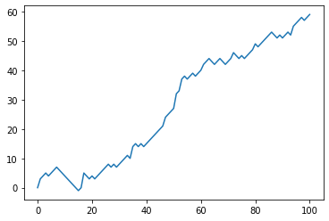

```python
# Import matplotlib.pyplot as plt
import matplotlib.pyplot as plt

# Plot random_walk
plt.plot(random_walk)

# Show the plot
plt.show()
```

```python
# Initialize all_walks
all_walks = []

# Simulate random walk 10 times
for i in range(10) :

    # Code from before
    random_walk = [0]
    for x in range(100) :
        step = random_walk[-1]
        dice = np.random.randint(1,7)

        if dice <= 2:
            step = max(0, step - 1)
        elif dice <= 5:
            step = step + 1
        else:
            step = step + np.random.randint(1,7)
        random_walk.append(step)

    # Append random_walk to all_walks
    all_walks.append(random_walk)

# Print all_walks
print(all_walks)
```

```
[[0, 4, 3, 2, 4, 3, 4, 6, 7, 8, 13, 12, 13, 14, 15, 16, 17, 16, 21, 22, 23, 24, 23, 22, 21, 20, 19, 20, 21, 22, 28, 27, 26, 25, 26, 27, 28, 27, 28, 29, 28, 33, 34, 33, 32, 31, 30, 31, 30, 29, 31, 32, 35, 36, 38, 39, 40, 41, 40, 39, 40, 41, 42, 43, 42, 43, 44, 45, 48, 49, 50, 49, 50, 49, 50, 51, 52, …
```

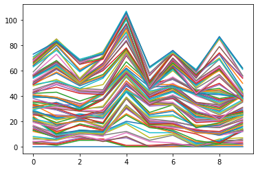

```python
# Convert all_walks to Numpy array: np_aw
np_aw = np.array(all_walks)

# Plot np_aw and show
plt.plot(np_aw)
plt.show()

# Clear the figure
plt.clf()
```

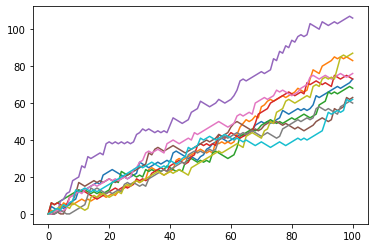

```python
# Transpose np_aw: np_aw_t
np_aw_t = np.transpose(np_aw)

# Plot np_aw_t and show
plt.plot(np_aw_t)
plt.show()
```

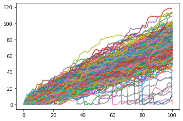

```python
#Implement clumsiness
# numpy and matplotlib imported, seed set

# Simulate random walk 250 times
all_walks = []
for i in range(250) :
    random_walk = [0]
    for x in range(100) :
        step = random_walk[-1]
        dice = np.random.randint(1,7)
        if dice <= 2:
            step = max(0, step - 1)
        elif dice <= 5:
            step = step + 1
        else:
            step = step + np.random.randint(1,7)

        # Implement clumsiness
        if np.random.rand()<= 0.001 :
            step = 0

        random_walk.append(step)
    all_walks.append(random_walk)

# Create and plot np_aw_t
np_aw_t = np.transpose(np.array(all_walks))
plt.plot(np_aw_t)
plt.show()
```

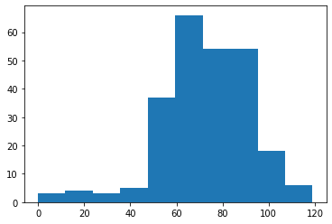

```python
# Select last row from np_aw_t: ends
ends = np_aw_t[-1,:]

# Plot histogram of ends, display plot
plt.hist(ends)
plt.show()
```

```python
np.mean(ends>60)
```

```
0.776
```

```python
import os
wd = os.getcwd()
os.listdir(wd)
```

[output not shown]

完结撒花！

[figure not shown]

[figure not shown]

2020-05-11

[figure not shown]